# Milestone Report

Vishal Balapure

June 14, 2018

## Introduction

This project analyzes the [HC Corpora Dataset](https://d396qusza40orc.cloudfront.net/dsscapstone/dataset/Coursera-SwiftKey.zip) with the end goal of creating a Shiny App for predicting n-grams. This first milestone report summarizes an exploratory data analysis.

## File Summary

Three data files sourced from blogs, news, and twitter were read into R. The news file had hidden null characters preventing a full file read and these null characters required hand deletion with Notepad++ prior to file loading.

| f_names | f_size | f_lines | n_char | n_words | pct_n_char | pct_lines | pct_words |
| --- | --- | --- | --- | --- | --- | --- | --- |
| blogs | 200.4242 | 899288 | 208361438 | 37334131 | 0.54 | 0.27 | 0.53 |
| news | 196.2775 | 77259 | 15683765 | 2643969 | 0.04 | 0.02 | 0.04 |
| twitter | 159.3641 | 2360148 | 162385035 | 30373583 | 0.42 | 0.71 | 0.43 |

Processing files of this size pushed up against R’s memory limits and ran slowly. To facilitate analysis, we sampled ten percent of the lines from each file. We cleaned the sample and created n-grams. To further speed processing, we subsetted the n-grams to those that covered 90% of the sample phrases. A fully reproducible version of this data analysis is available on [Github.](https://github.com/mark-blackmore/JHU-Data-Science-Capstone/blob/master/02_Task_Script.md)

## Uni-grams

The corpora are populated with many acronyms and abbreviations such as “rt” for re-tweet, “lol” for laugh out loud, “ic” for I see. Notably, we chose to leave the short hand “im” for I am and “dont” for don’t / do not as is, hence they show up as uni-grams.

### Uni-gram Wordcloud

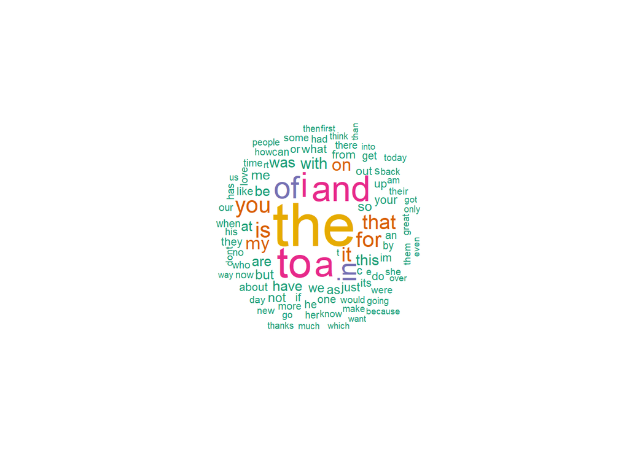

### Uni-grms, By Source

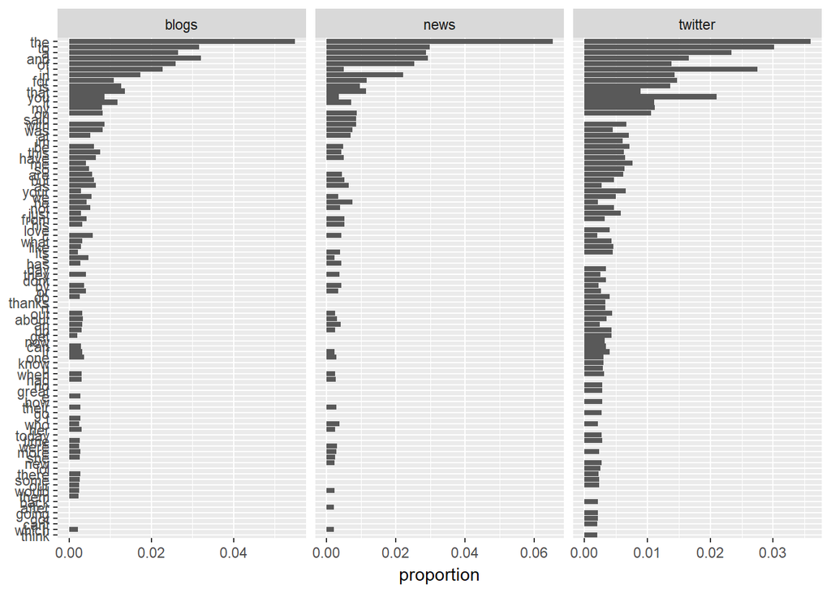

## Uni-gram Distribution

Distributions were created for each set of n-grams, based on relative frequency.

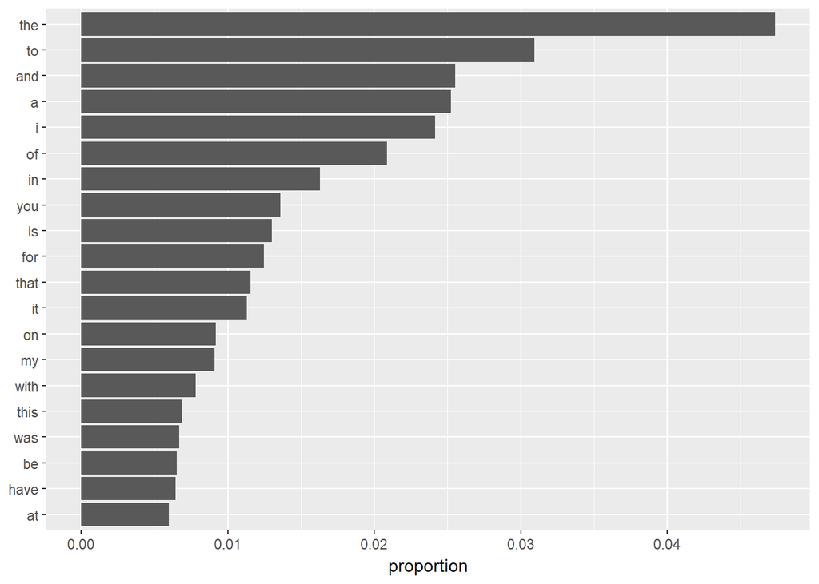

## Bi-gram Distribution

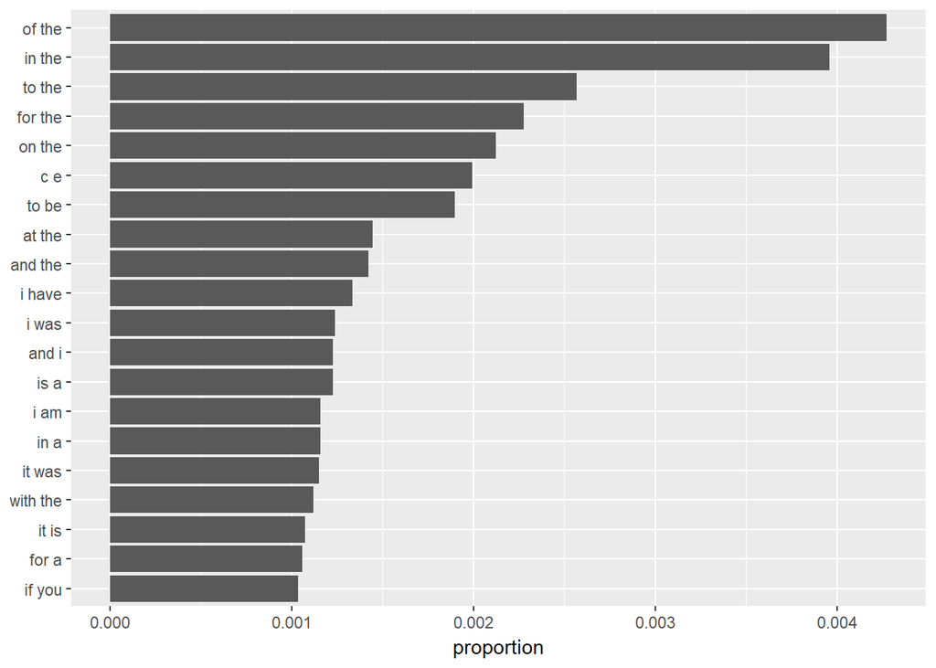

## Tri-gram Distribution

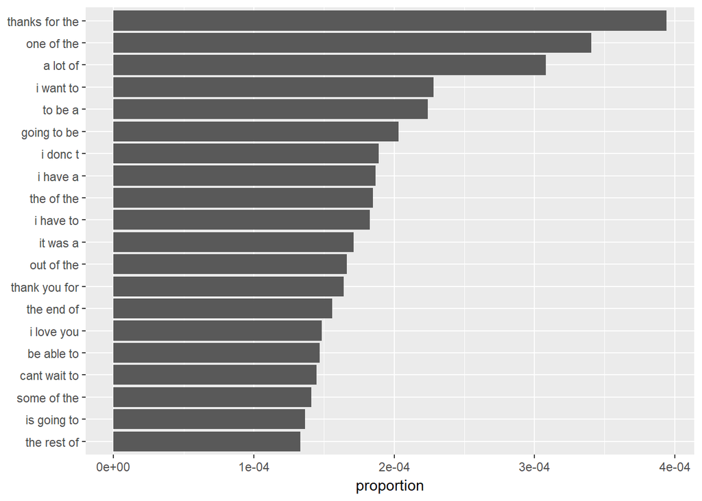

## Quad-gram Distribution

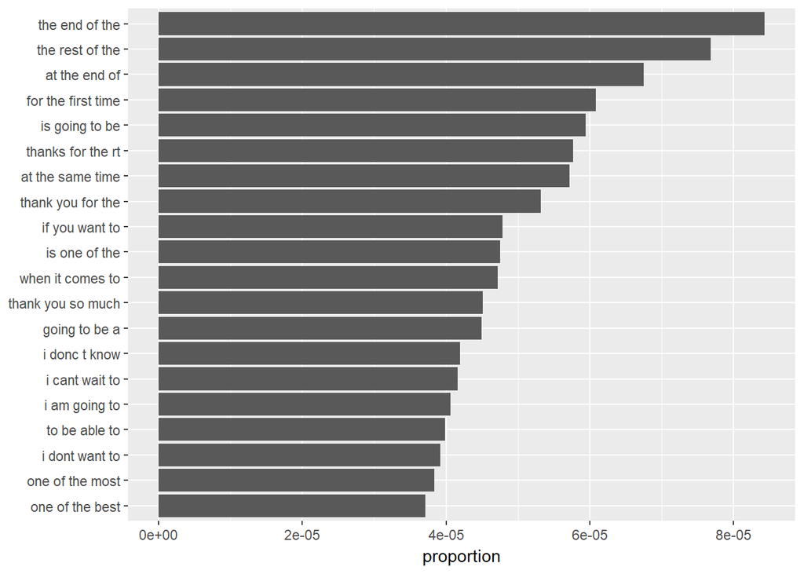

## N-gram Prediction Model

I anticipate using the n-gram tables created for bi-gram, tri-grams, and quad-grams as the basis for prediction. The user will input a word, the model will find the bi-gram with the greatest relative frequency given that word. Similarly, the tri-gram table will be used for making predictions from two word entries and so on.

| word1 | word2 | word3 | word4 | n | proportion | coverage |
| --- | --- | --- | --- | --- | --- | --- |
| the | end | of | the | 525 | 8.43e-05 | 0.0000843 |
| the | rest | of | the | 478 | 7.68e-05 | 0.0001611 |
| at | the | end | of | 420 | 6.74e-05 | 0.0002285 |
| for | the | first | time | 379 | 6.09e-05 | 0.0002894 |
| is | going | to | be | 370 | 5.94e-05 | 0.0003488 |
| thanks | for | the | rt | 359 | 5.77e-05 | 0.0004065 |

Notice in the guad-gram table, that the 4-grams are separated by word and arranged by relative frequency. When the user inputs three words, the model matches those words and then finds the fourth word with the greatest relative frequency. Cases where there is no match, or where more than three words are entered, will have random completion.